# CS329e Data Visualization R Project 1

Nathan Waters, Lerone Williams

In this R Markdown document we will display and document each step of CS329e R Project 1.

Project Requirements http://www.cs.utexas.edu/~cannata/dataVis/Projects/R%20Project%201/R%20Project%20Requirements.html.

In the source folder 01 Data, the R script dataframes.R was created to connect to Dr. Cannata’s Orcale database and generate 5 data frames using tables in the Orders Schema. The RCurl package was loaded to allow general HTTP requests and process the results returned by the Web server.

```r
source("../01 Data/dataframes.R", echo = TRUE)
```

```
##
## > library("RCurl")
```

```
##
## > df1 <- data.frame(eval(parse(text = substring(getURL(URLencode("http://129.152.144.84:5001/rest/native/?query=\"select * from customers\""),
## +      .... [TRUNCATED]
##
## > df2 <- data.frame(eval(parse(text = substring(getURL(URLencode("http://129.152.144.84:5001/rest/native/?query=\"select * from items\""),
## +     http .... [TRUNCATED]
##
## > df3 <- data.frame(eval(parse(text = substring(getURL(URLencode("http://129.152.144.84:5001/rest/native/?query=\"select * from orders\""),
## +     htt .... [TRUNCATED]
##
## > df4 <- data.frame(eval(parse(text = substring(getURL(URLencode("http://129.152.144.84:5001/rest/native/?query=\"select * from order_details\""),
## +  .... [TRUNCATED]
##
## > df5 <- data.frame(eval(parse(text = substring(getURL(URLencode("http://129.152.144.84:5001/rest/native/?query=\"select * from orders o join customer .... [TRUNCATED]
```

A second R script dataframes1.R was created to display each data frame that was previously created in the last step. The head() function was used to only return the first parts of each data frame.

```r
source("../01 Data/dataframes1.R", echo = TRUE)
```

```
##
## > head(df1)
##   CUSTOMER_ID CUSTOMER_FIRST_NAME CUSTOMER_LAST_NAME      CUSTOMER_ADDRESS
## 1           1               Korah             Blanca       1555 W Lane Ave
## 2           2                Yash            Randall 11 E Rancho Madera Rd
## 3           3           Johnathon          Millerton        60 Madison Ave
## 4           4             Mikayla             Damion      2021 K Street Nw
## 5           5             Kendall              Mayte 4775 E Miami River Rd
## 6           6             Kaitlin           Hostlery 3250 Spring Grove Ave
##   CUSTOMER_CITY CUSTOMER_STATE CUSTOMER_ZIP CUSTOMER_PHONE CUSTOMER_FAX
## 1      Columbus             OH        43221     6145554432   6145553920
## 2       Madison             WI        53707     2095551205   2095552262
## 3      New York             NY        10010     2125554800         NULL
## 4    Washington             DC        20006     2025555561         NULL
## 5        Cleves             OH        45002     5135553024         NULL
```

[output cut: 35 more lines]

In order to plot each data frame, the ggplot2 package was loaded and a different geom, short for geometric objects was chosen as follows: df1 = geom_point(), df2 = geom_path(), df3 = geom_density2d(), df4 = geom_dotplot()

```
##
## > library("ggplot2")
##
## > ggplot(df1, aes(x = CUSTOMER_STATE, y = CUSTOMER_ID)) +
## +     geom_point()
```

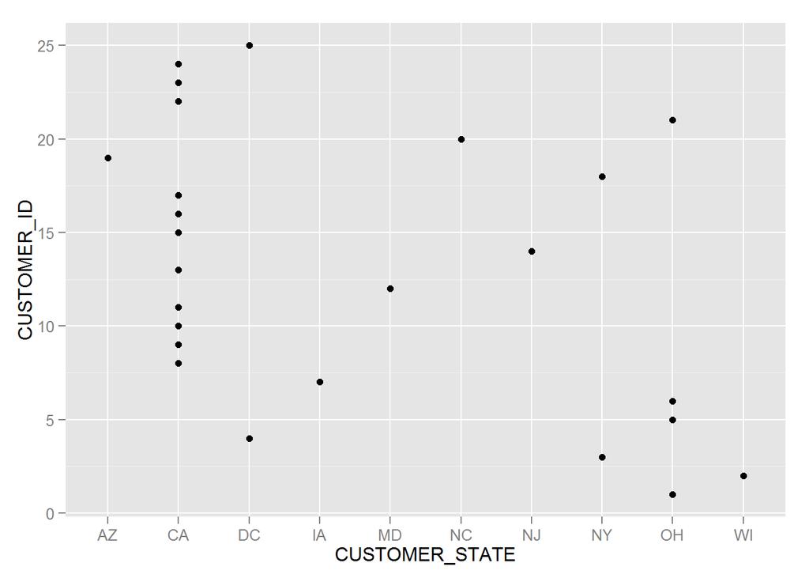

```
##
## > ggplot(df2, aes(x = ITEM_ID, y = UNIT_PRICE)) + geom_path()
```

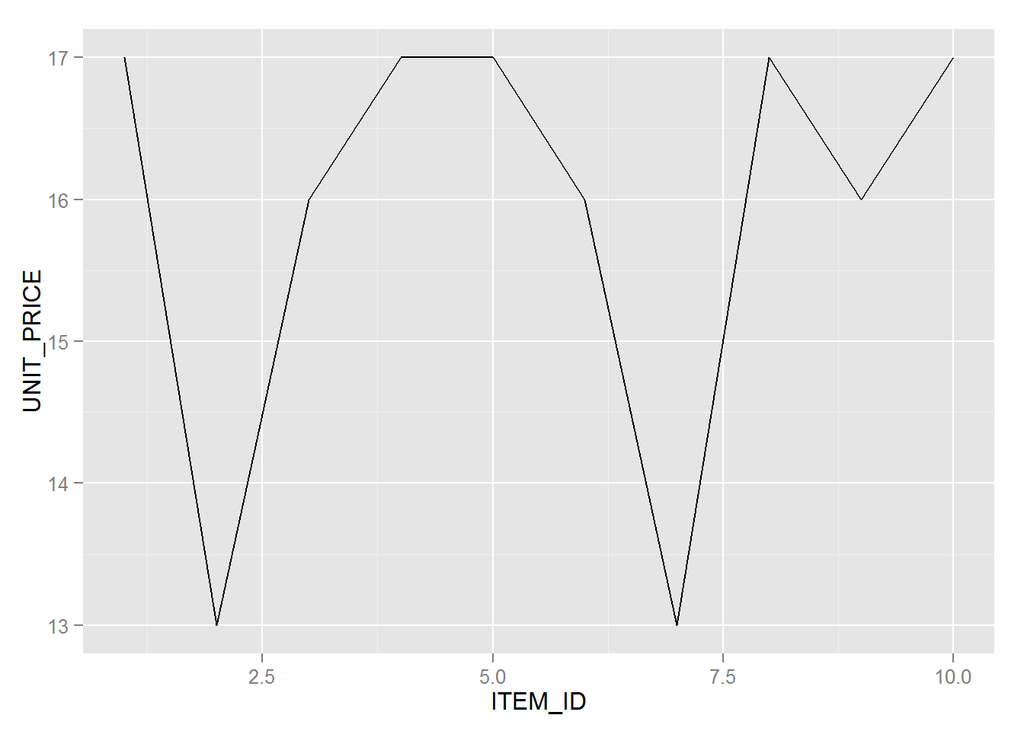

```
##
## > ggplot(df3, aes(x = ORDER_ID, y = CUSTOMER_ID)) +
## +     geom_density2d()
```

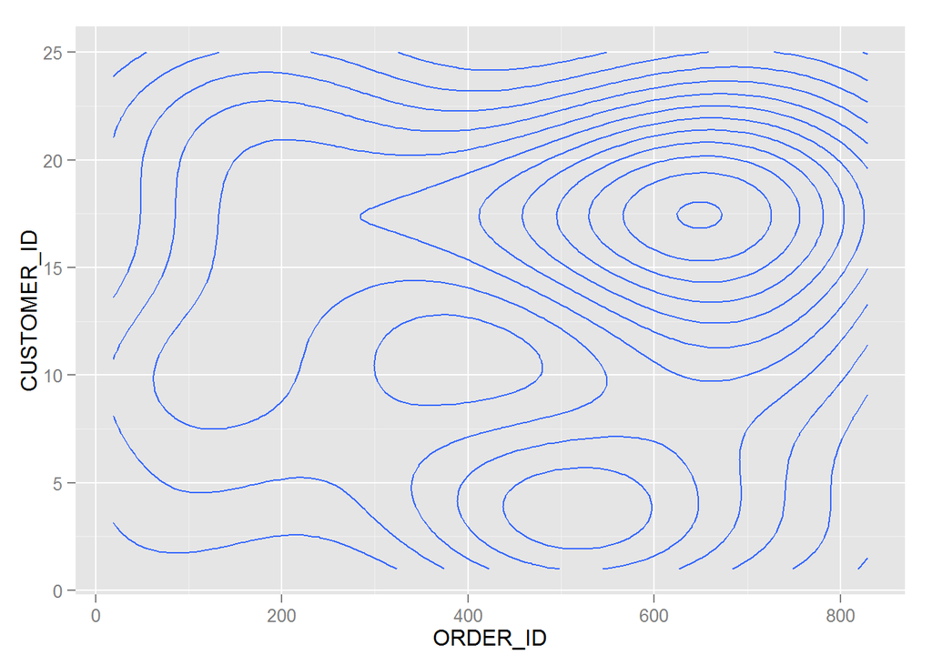

```
##
## > ggplot(df4, aes(x = ORDER_ID, y = ITEM_ID)) + geom_dotplot()
```

```
## stat_bindot: binwidth defaulted to range/30. Use 'binwidth = x' to adjust this.
```

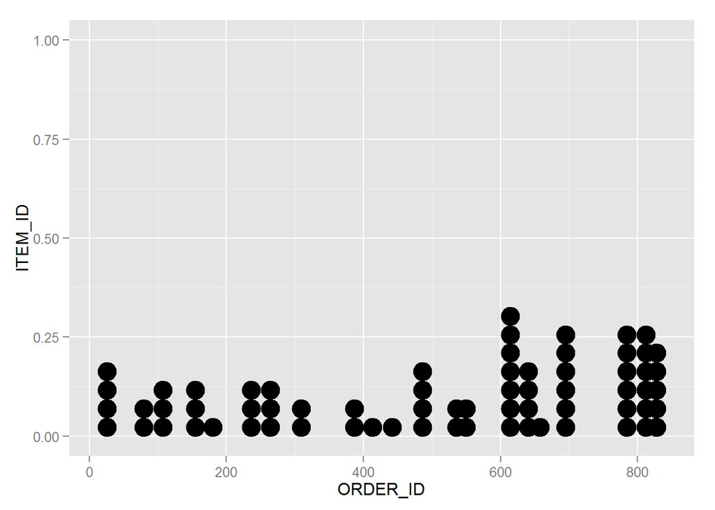

```r
source("../02 Visualizations/ggplot.R", echo = TRUE)
```

Finally, using the df5 data frame created from the entire data set, the following three plots were produced.

```
##
## > q <- ggplot(df5, aes(x = as.Date(SHIPPED_DATE, "%Y-%m-%d"),
## +     y = as.Date(ORDER_DATE, "%Y-%m-%d"))) + geom_point(aes(color = as.factor(UNIT_PRI .... [TRUNCATED]
##
## > q + facet_wrap(~CUSTOMER_STATE)
```

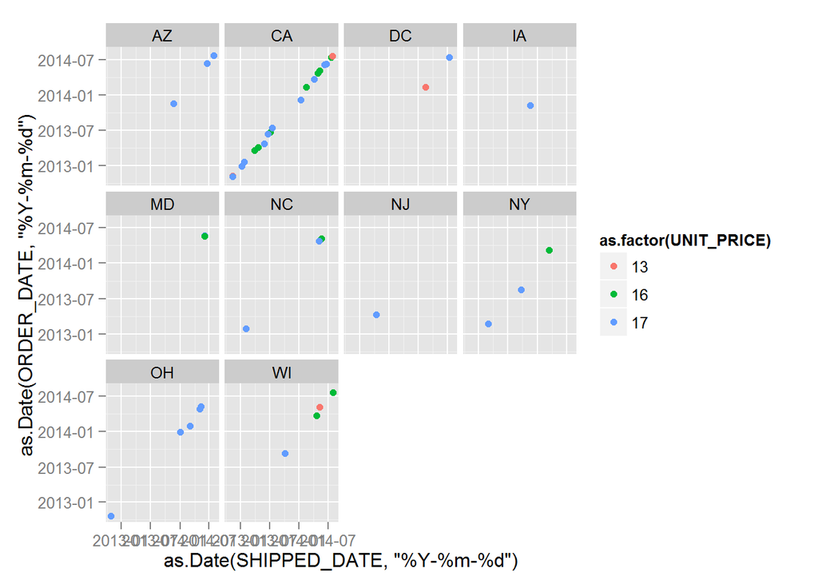

```
##
## > s <- ggplot(df5, aes(x = as.Date(SHIPPED_DATE, "%Y-%m-%d"),
## +     y = as.Date(ORDER_DATE, "%Y-%m-%d"))) + geom_point(aes(color = as.factor(TITLE)))
##
## > s + facet_wrap(~CUSTOMER_STATE)
```

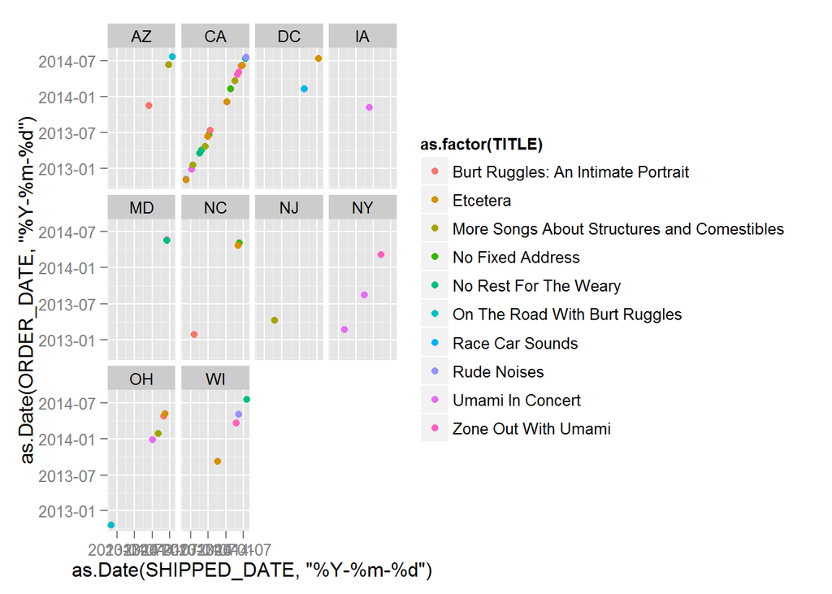

```
##
## > t <- ggplot(df5, aes(x = as.Date(SHIPPED_DATE, "%Y-%m-%d"),
## +     y = as.Date(ORDER_DATE, "%Y-%m-%d"))) + geom_point(aes(color = as.factor(ARTIST)) .... [TRUNCATED]
##
## > t + facet_wrap(~CUSTOMER_STATE)
```

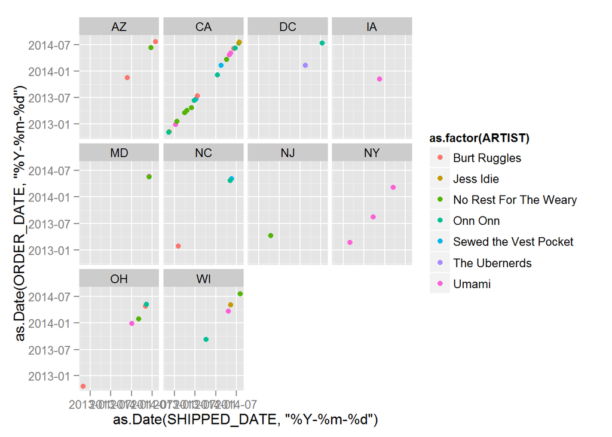

```r
source("../02 Visualizations/ggplot1.R", echo = TRUE)
```